# Lab 4 - HW 5 Econometrics

Vanessa Crowe, Luis Melo, Mishal Nawaz

2023-10-05

## Regression Modeling by Wages in R

For this lab we will be looking into people at prime age in the labor force who work fulltime, year round according to NYs ACS data from 2017. We will call this subset “data_use”

```r
load("~/Desktop/Econometrics R Projects/acs2017_ny_data.RData")
use_varb <- (acs2017_ny$AGE >= 25) & (acs2017_ny$AGE <= 55) & (acs2017_ny$LABFORCE == 2) & (acs2017_ny$WKSWORK2 > 4) & (acs2017_ny$UHRSWORK >= 35)
dat_use <- subset(acs2017_ny,use_varb)
summary(dat_use)
```

```
##       AGE           female         educ_nohs         educ_hs
##  Min.   :25.0   Min.   :0.0000   Min.   :0.0000   Min.   :0.0000
##  1st Qu.:33.0   1st Qu.:0.0000   1st Qu.:0.0000   1st Qu.:0.0000
##  Median :41.0   Median :0.0000   Median :0.0000   Median :0.0000
##  Mean   :40.5   Mean   :0.4526   Mean   :0.0466   Mean   :0.2579
##  3rd Qu.:49.0   3rd Qu.:1.0000   3rd Qu.:0.0000   3rd Qu.:1.0000
##  Max.   :55.0   Max.   :1.0000   Max.   :1.0000   Max.   :1.0000
##
##  educ_somecoll   educ_college     educ_advdeg                   SCHOOL
##  Min.   :0.00   Min.   :0.0000   Min.   :0.0000   N/A              :    0
##  1st Qu.:0.00   1st Qu.:0.0000   1st Qu.:0.0000   No, not in school:44768
##  Median :0.00   Median :0.0000   Median :0.0000   Yes, in school   : 2203
##  Mean   :0.21   Mean   :0.2775   Mean   :0.2079   Missing          :    0
##  3rd Qu.:0.00   3rd Qu.:1.0000   3rd Qu.:0.0000
##  Max.   :1.00   Max.   :1.0000   Max.   :1.0000
##
##                   EDUC
##  4 years of college :13035
##  Grade 12           :12116
##  5+ years of college: 9766
##  2 years of college : 5013
##  1 year of college  : 4852
##  Grade 5, 6, 7, or 8:  617
##  (Other)            : 1572
##                                           EDUCD
##  Bachelor's degree                           :13035
##  Regular high school diploma                 : 7768
##  Master's degree                             : 7069
##  Associate's degree, type not specified      : 5013
##  1 or more years of college credit, no degree: 4852
##  Some college, but less than 1 year          : 2210
##  (Other)                                     : 7024
##                                      DEGFIELD
##  N/A                                     :24170
##  Business                                : 4836
##  Social Sciences                         : 2178
##  Education Administration and Teaching   : 1859
##  Medical and Health Sciences and Services: 1481
##  Fine Arts                               : 1432
##  (Other)                                 :11015
```

[output cut: 201 more lines]

```
##  Min.   :0.0000   Min.   :0.0000   Min.   :0.0000   Min.   :0.00000
##  1st Qu.:0.0000   1st Qu.:0.0000   1st Qu.:0.0000   1st Qu.:0.00000
##  Median :0.0000   Median :0.0000   Median :0.0000   Median :0.00000
##  Mean   :0.0377   Mean   :0.1845   Mean   :0.0344   Mean   :0.09576
##  3rd Qu.:0.0000   3rd Qu.:0.0000   3rd Qu.:0.0000   3rd Qu.:0.00000
##  Max.   :1.0000   Max.   :1.0000   Max.   :1.0000   Max.   :1.00000
##
##  below_povertyline below_150poverty  below_200poverty   foodstamps
##  Min.   :0.00000   Min.   :0.00000   Min.   :0.0000   Min.   :0.00000
##  1st Qu.:0.00000   1st Qu.:0.00000   1st Qu.:0.0000   1st Qu.:0.00000
##  Median :0.00000   Median :0.00000   Median :0.0000   Median :0.00000
##  Mean   :0.02169   Mean   :0.06119   Mean   :0.1167   Mean   :0.07083
##  3rd Qu.:0.00000   3rd Qu.:0.00000   3rd Qu.:0.0000   3rd Qu.:0.00000
##  Max.   :1.00000   Max.   :1.00000   Max.   :1.0000   Max.   :1.00000
##
```

We then model this subset into a Linear regression of Income Wage against Age with additional arguments of race and education

```r
model_temp1 <- lm(INCWAGE ~ AGE + AfAm + Asian + Amindian + race_oth + Hispanic + educ_hs + educ_somecoll + educ_college + educ_advdeg, data = dat_use)

require(stargazer)
stargazer(model_temp1, type = "text")
```

```
##
## ===============================================
##                         Dependent variable:
##                     ---------------------------
##                               INCWAGE
## -----------------------------------------------
## AGE                        1,309.133***
##                              (40.163)
##
## AfAm                      -15,172.130***
##                             (1,140.767)
##
## Asian                         774.020
##                             (1,387.175)
##
## Amindian                    -9,586.509
##                             (6,154.668)
##
## race_oth                   -7,862.011***
##                             (1,288.568)
##
## Hispanic                   -5,168.732***
##                             (1,198.144)
##
## educ_hs                    9,418.920***
##                             (1,837.378)
##
## educ_somecoll              18,941.360***
##                             (1,878.388)
##
## educ_college               53,159.010***
##                             (1,850.468)
##
## educ_advdeg                76,904.700***
##                             (1,894.694)
##
## Constant                  -14,171.300***
##                             (2,469.049)
##
## -----------------------------------------------
## Observations                  46,971
## R2                             0.128
## Adjusted R2                    0.128
## Residual Std. Error   77,728.370 (df = 46960)
## F Statistic         691.440*** (df = 10; 46960)
## ===============================================
## Note:               *p<0.1; **p<0.05; ***p<0.01
```

Below we are now creating a random subset of the data in Income and selecting 10% of these observations. It will create a cleaner visualization when plotted.

We are creating a scatter plot with a jitter affect of 1 to give “noise” to the income values at each age so we can see less overlapping of data values.

There were also a set of outliers with significantly high income that is off the charts, we therefor have set a limit of 150k to our plot.

```r
require(AER)
```

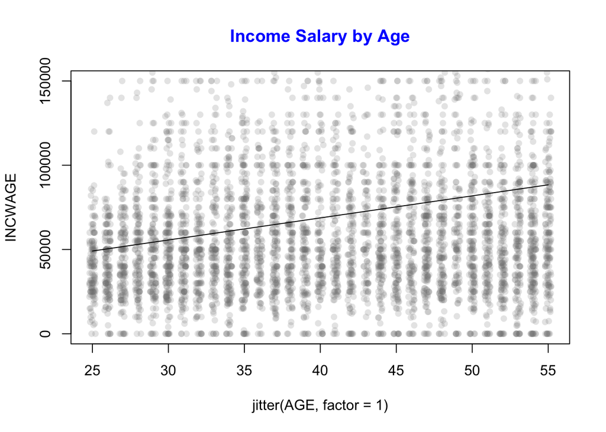

```r
NNobs <- length(dat_use$INCWAGE)
set.seed(12345)
graph_obs <- (runif(NNobs) < 0.1)
dat_graph <-subset(dat_use,graph_obs)

plot(INCWAGE ~ jitter(AGE, factor = 1), pch = 16, col = rgb(0.5, 0.5, 0.5, alpha = 0.2), ylim = c(0,150000), data = dat_graph)
title(main = "Income Salary by Age", col.main = "blue")


to_be_predicted2 <- data.frame(AGE = 25:55, AfAm = 0, Asian = 0, Amindian = 1, race_oth = 1, Hispanic = 1, educ_hs = 0, educ_somecoll = 0, educ_college = 1, educ_advdeg = 0)

to_be_predicted2$yhat <- predict(model_temp1, newdata = to_be_predicted2)

lines(yhat ~ AGE, data = to_be_predicted2)
```

In Scatter plot “Income Salary by Age” we proceeded to create predicted values of Income based on age and certain races such as Amindian = 1, race_oth = 1, Hispanic = 1 as well as educ_college = 1 to create a line called Yhat This line shows that the values of income range between about 49099 and 88373, shown by the min and max of the below summary

```r
summary(to_be_predicted2$yhat)
```

```
##    Min. 1st Qu.  Median    Mean 3rd Qu.    Max.
##   49099   58917   68736   68736   78554   88373
```